# Effects of Signaling Environment and Diet Conditions on Mate Choice in the Wolf Spider *Schizocosa mccooki*

Yihang Park

2023-12-13

```r
mccooki <- read.csv("data/mccooki.csv")
library(tidyverse)
library(dplyr)
library(nnet)
library(car)
library(lmtest)
library(ggplot2)
```

# **Part 0**: Basic data wrangling

Since the raw data is super old and the columns are named and written in an inconvenient manner, let’s proceed to tidy up.

```r
# since both the visual and vibrational signaling environments are coded in a single column in a peculiar manner (+/+, +/-, -/+, -/-), please separate them into individual columns
# create a binary 'copsuccess' column by converting the 'coptime' column, assigning 1 for copulated and 0 for not copulated
mccooki=mccooki %>%
  mutate(light.condition=pull(mccooki, Cond..Lt.S.) %>% str_sub(start=1, end=1)) %>%
  mutate(substrate.condition=pull(mccooki, Cond..Lt.S.) %>% str_sub(start=3, end=3)) %>%
  mutate(cop.success=(X1st.cop.Time!="")+0)

# change weird column name
colnames(mccooki)[colnames(mccooki) == "X1st.Cop.Male"] ="firstcop.male"

# assign categorical variables as a factor
mccooki$firstcop.male <-as.factor (mccooki$firstcop.male)
mccooki$Fcond <-as.factor (mccooki$Fcond)
mccooki$light.condition <-as.factor(mccooki$light.condition)
mccooki$substrate.condition <-as.factor(mccooki$substrate.condition)
mccooki$Cond..Lt.S. <-as.factor (mccooki$Cond..Lt.S.)
```

Since in the original data(mccooki) response variable (the first male copulated with female) is 3 levels factor including NAs(High-diet vs low-diet vs NA), make another dataframe (mccooki2) with response variable with 2-levels factor excluding NAs (High-diet vs Low-diet).

```r
# remove the NAs from the response variable to convert it into a two-level factor (LD vs HD)
mccooki2 <- mccooki %>%
  filter(!firstcop.male=="na") %>%
  mutate(firstcop.male = factor(firstcop.male))
```

# **Part 1**: Run various statistical tests!

### **1.1**: Did the signaling environment and/or female diet influence whether females copulated during the trial in the simultaneous choice test?

```r
# Performing a generalized linear model with all covariates included
glm.copsuccess <- glm(cop.success~ Fcond*light.condition*substrate.condition, family=binomial(link="logit"),data=mccooki2)
summary(glm.copsuccess)
```

```
##
## Call:
## glm(formula = cop.success ~ Fcond * light.condition * substrate.condition,
##     family = binomial(link = "logit"), data = mccooki2)
##
## Coefficients:
##                                                  Estimate Std. Error z value
## (Intercept)                                     1.946e+00  1.069e+00   1.820
## Fcondlow                                        1.862e+01  8.865e+03   0.002
## light.condition+                                1.862e+01  5.607e+03   0.003
## substrate.condition+                           -2.289e-15  1.512e+00   0.000
## Fcondlow:light.condition+                      -1.862e+01  1.635e+04  -0.001
## Fcondlow:substrate.condition+                  -2.002e-10  1.535e+04   0.000
## light.condition+:substrate.condition+           1.535e-08  7.929e+03   0.000
## Fcondlow:light.condition+:substrate.condition+ -3.379e-08  2.775e+04   0.000
##                                                Pr(>|z|)
## (Intercept)                                      0.0687 .
## Fcondlow                                         0.9983
## light.condition+                                 0.9974
## substrate.condition+                             1.0000
## Fcondlow:light.condition+                        0.9991
## Fcondlow:substrate.condition+                    1.0000
## light.condition+:substrate.condition+            1.0000
## Fcondlow:light.condition+:substrate.condition+   1.0000
## ---
## Signif. codes:  0 '***' 0.001 '**' 0.01 '*' 0.05 '.' 0.1 ' ' 1
##
## (Dispersion parameter for binomial family taken to be 1)
##
##     Null deviance: 16.364  on 44  degrees of freedom
## Residual deviance: 12.057  on 37  degrees of freedom
## AIC: 28.057
##
## Number of Fisher Scoring iterations: 19
```

none of the predictors showed significance.

### **1.2**: Did the signaling environment and/or female diet influence the female’s choice between males on high and low diets for copulation?

Establish multinomial logistic regression models by progressively including different covariates in a hierarchical manner.

```r
# let's run multinomial logistic regression analysis  where the response variable is 1st copulated males: Low vs High diet
model1 <-multinom(firstcop.male ~ light.condition ,data=mccooki2)
model2 <-multinom(firstcop.male ~ substrate.condition ,data=mccooki2)
model3 <-multinom(firstcop.male ~ light.condition + substrate.condition ,data=mccooki2)
model4 <-multinom(firstcop.male ~ light.condition * substrate.condition ,data=mccooki2)
model5 <-multinom(firstcop.male ~ Fcond + light.condition * substrate.condition, data=mccooki2)
model6 <-multinom(firstcop.male ~ Fcond * light.condition * substrate.condition ,data=mccooki2)
```

#### **1.2.1**: getting p-values for each predictors

##### **1.2.1.1**: ANOVA conducted on the full model including all covariates.

```r
car::Anova(model6)
```

```
## Analysis of Deviance Table (Type II tests)
##
## Response: firstcop.male
##                                           LR Chisq Df Pr(>Chisq)
## Fcond                                       0.6514  1    0.41961
## light.condition                             0.0053  1    0.94188
## substrate.condition                         4.0840  1    0.04329 *
## Fcond:light.condition                       1.2527  1    0.26303
## Fcond:substrate.condition                   0.0023  1    0.96216
## light.condition:substrate.condition         0.2089  1    0.64763
## Fcond:light.condition:substrate.condition   0.6873  1    0.40708
## ---
## Signif. codes:  0 '***' 0.001 '**' 0.01 '*' 0.05 '.' 0.1 ' ' 1
```

The presence or absence of vibratory signals affected female choice.

##### **1.2.1.2**: Likelihood ratio tests are conducted to manually compare models and obtain p-values for each predictor.

```r
# likelihood ratio test to manually compare the fit of models
lrtest(model1, model3) #significant effects of vibratory signals
```

```
## Likelihood ratio test
##
## Model 1: firstcop.male ~ light.condition
## Model 2: firstcop.male ~ light.condition + substrate.condition
##   #Df  LogLik Df  Chisq Pr(>Chisq)
## 1   2 -30.278
## 2   3 -28.076  1 4.4051    0.03583 *
## ---
## Signif. codes:  0 '***' 0.001 '**' 0.01 '*' 0.05 '.' 0.1 ' ' 1
```

```r
lrtest(model2, model3) #non-significant effects of visual signals
```

```
## Likelihood ratio test
##
## Model 1: firstcop.male ~ substrate.condition
## Model 2: firstcop.male ~ light.condition + substrate.condition
##   #Df  LogLik Df  Chisq Pr(>Chisq)
## 1   2 -28.078
## 2   3 -28.076  1 0.0058     0.9393
```

```r
lrtest(model3, model4) #non-significant interaction effects of visual/vibratory signals
```

```
## Likelihood ratio test
##
## Model 1: firstcop.male ~ light.condition + substrate.condition
## Model 2: firstcop.male ~ light.condition * substrate.condition
##   #Df  LogLik Df  Chisq Pr(>Chisq)
## 1   3 -28.076
## 2   4 -27.918  1 0.3159     0.5741
```

```r
lrtest(model4, model5) #non-significant effects of female diet
```

```
## Likelihood ratio test
##
## Model 1: firstcop.male ~ light.condition * substrate.condition
## Model 2: firstcop.male ~ Fcond + light.condition * substrate.condition
##   #Df  LogLik Df  Chisq Pr(>Chisq)
## 1   4 -27.918
## 2   5 -27.592  1 0.6514     0.4196
```

The presence or absence of vibratory signals affected female choice.

##### **1.2.1.3**: To determine the model with the best goodness of fit, let’s use a stepwise algorithm to select a model based on AIC. We’ll start with a full model containing all covariates (model6).

```r
AIC.Bestfit <-step(model6)
```

```
## Start:  AIC=69.24
## firstcop.male ~ Fcond * light.condition * substrate.condition
##
## trying - Fcond:light.condition:substrate.condition
##                                             Df      AIC
## - Fcond:light.condition:substrate.condition  7 67.93061
## <none>                                       8 69.24328
##
## Step:  AIC=67.93
## firstcop.male ~ Fcond + light.condition + substrate.condition +
##     Fcond:light.condition + Fcond:substrate.condition + light.condition:substrate.condition
##
## trying - Fcond:light.condition
## trying - Fcond:substrate.condition
## trying - light.condition:substrate.condition
##                                       Df      AIC
## - Fcond:substrate.condition            6 65.93286
## - light.condition:substrate.condition  6 66.13951
## - Fcond:light.condition                6 67.18335
## <none>                                 7 67.93061
##
## Step:  AIC=65.93
## firstcop.male ~ Fcond + light.condition + substrate.condition +
##     Fcond:light.condition + light.condition:substrate.condition
##
## trying - Fcond:light.condition
## trying - light.condition:substrate.condition
##                                       Df      AIC
## - light.condition:substrate.condition  5 64.16844
## - Fcond:light.condition                5 65.18377
## <none>                                 6 65.93286
##
## Step:  AIC=64.17
## firstcop.male ~ Fcond + light.condition + substrate.condition +
##     Fcond:light.condition
##
## trying - substrate.condition
## trying - Fcond:light.condition
##                         Df      AIC
## - Fcond:light.condition  4 63.48108
```

[output cut: 17 more lines]

```
##
## trying - Fcond
## trying - substrate.condition
##                       Df      AIC
## - Fcond                2 60.15693
## <none>                 3 61.48639
## - substrate.condition  2 63.45725
##
## Step:  AIC=60.16
## firstcop.male ~ substrate.condition
##
## trying - substrate.condition
##                       Df      AIC
## <none>                 2 60.15693
## - substrate.condition  1 62.57105
```

The model that solely included the vibratory signal environment as a predictor demonstrated the best goodness of fit.Let’s use this model to run an ANOVA and obtain the p-value of the predictor.

```r
car::Anova(AIC.Bestfit)
```

```
## Analysis of Deviance Table (Type II tests)
##
## Response: firstcop.male
##                     LR Chisq Df Pr(>Chisq)
## substrate.condition   4.4141  1    0.03564 *
## ---
## Signif. codes:  0 '***' 0.001 '**' 0.01 '*' 0.05 '.' 0.1 ' ' 1
```

The reduced/best-fit model also suggests that the presence or absence of vibratory signals affected female choice.

# **Part 2**: Plotting

**Figure 1**: Does the condition of the female and the signaling environment influence copulation success or female receptivity? Plot bar graph with x axis is differing signaling environment and y axis is a proportion of trials with copulation

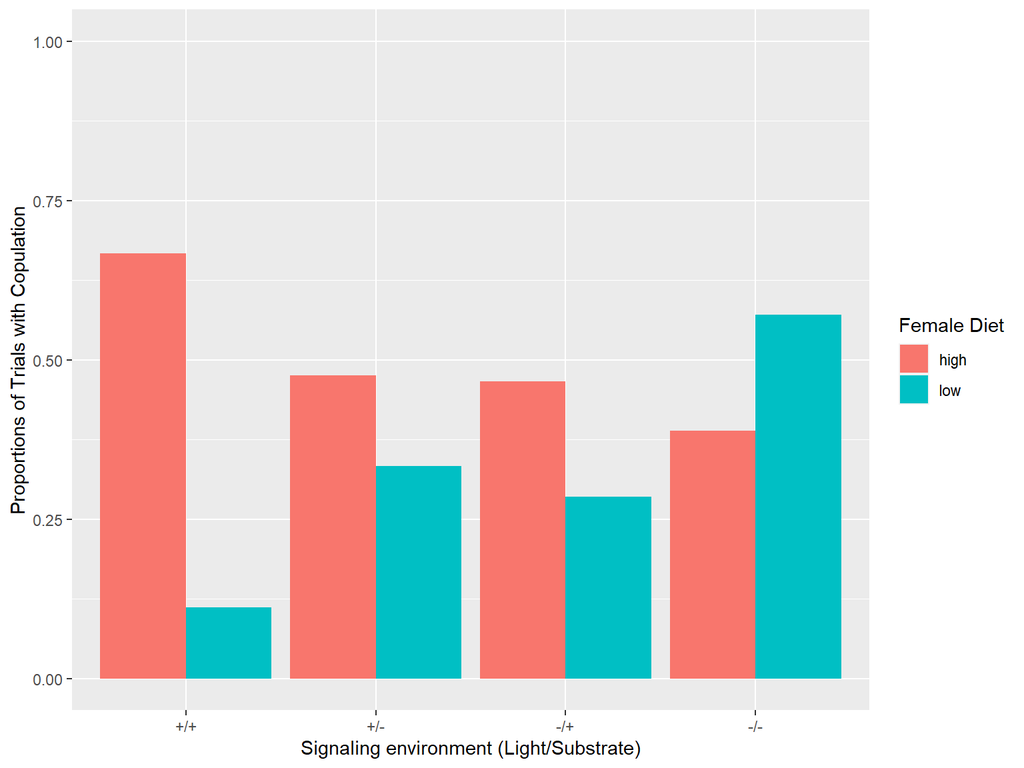

```r
# Reorder the sequence of categories displayed on the x-axis
mccooki$Cond..Lt.S.<- factor(mccooki$Cond..Lt.S., levels= c("+/+", "+/-", "-/+", "-/-"))

# To convert the y-axis into a proportion of trials with copulation (ranging from 0 to 1), create a new column indicating the mean copulation success
mccooki <- mccooki %>%
  group_by(Cond..Lt.S., Fcond) %>%
  mutate(Proportion = mean(cop.success))

# Plot a bar graph
ggplot(data=mccooki, aes(x = Cond..Lt.S., y = Proportion, fill = Fcond)) +
  geom_bar(stat = "identity", position = "dodge")+
  labs( x= "Signaling environment (Light/Substrate)", y= "Proportions of Trials with Copulation", fill= "Female Diet")+
  scale_fill_discrete(labels=c("h" = "High", "l" = "Low"))+
  ylim(0,1)
```

**Figure 2**: Do female choice vary by signaling environment and male quality?

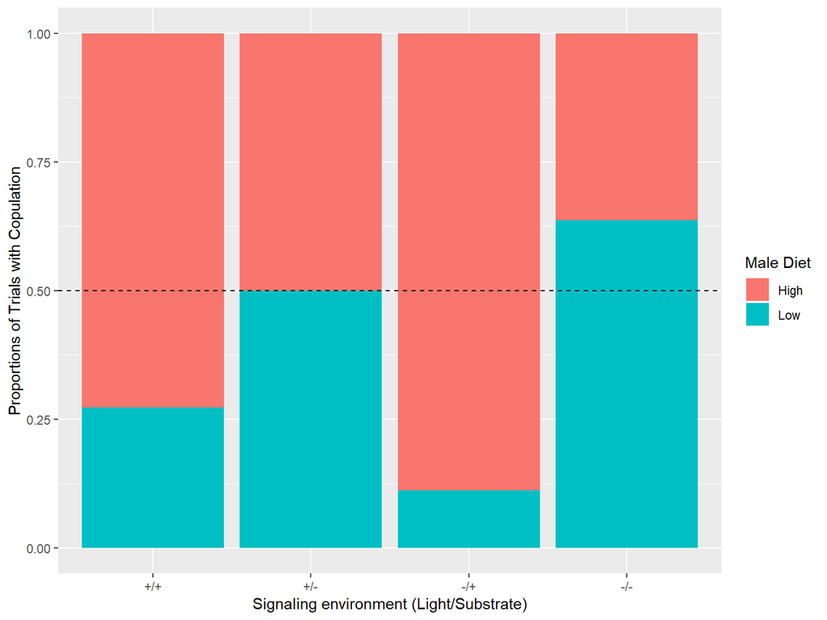

```r
mccooki2$Cond..Lt.S.<- factor(mccooki2$Cond..Lt.S., levels= c("+/+", "+/-", "-/+", "-/-"))
ggplot(data=mccooki2, aes(x = Cond..Lt.S., y = cop.success, fill = firstcop.male)) +
  geom_col( position = "fill") +

# Insert a vertical line at y=0.5, representing the null hypothesis that females exhibit no preference between low and high diet males in this experiment's simultaneous mate choice.
  geom_hline(yintercept = 0.5, linetype = "dashed", color = "black")+
  labs( x= "Signaling environment (Light/Substrate)", y= "Proportions of Trials with Copulation", fill= "Male Diet")+
  scale_fill_discrete(labels=c("h" = "High", "l" = "Low"))
```